# Lecture #9: Model Evaluation and Selection

## AM 207: Advanced Scientific Computing

### Stochastic Methods for Data Analysis, Inference and Optimization

### Fall, 2019

[figure not shown]

## Administrative Matters

1. **Attendance Quiz:**

## Outline

1. Review of Statistical Modeling
2. Motivation for Hierarchical Models
3. Hierarchical Models and Empirical Bayes

# Review of Statistical Modeling

## What We Can Do So Far: Models

1. **(Likelihood Models with Observed Variables)** When we have observed data $Y_{\text{Obs}}$, we can model $Y_{\text{Obs}}$ as a random variable $Y_{\text{Obs}} \sim p(Y |\theta)$ with a known distribution $p$.
   - if $Y_{\text{Obs}}$ is a label, we can model it as a *Categorical* or *Bernoulli* variable
   - if $Y_{\text{Obs}}$ is a count, we can model it as a *Binomial*, *Multinomial* or *Poisson*
   - if $Y_{\text{Obs}}$ is continuous, we can model it as a *Gaussian*, *Exponential*, *Dirichlet* etc
2. **(Likelihood Models with Latent Variables)** When we also have unobserved data $Z_{\text{Latent}}$, we can model $Z_{\text{Latent}}$ and $Y_{\text{Obs}}$ jointly $p(Y_{\text{Obs}}, Z_{\text{Latent}}| \theta)$.
3. **(Bayesian Models)** When we are being Bayesian, we *assume* a prior for $\theta$, encoding our knowledge and uncertainty about $\theta$. We model parameters and data jointly $p(Y_{\text{Obs}}, \theta)$ or $p(Y_{\text{Obs}}, Z_{\text{Latent}}, \theta)$.

## What We Can Do So Far: Inference

We can make statements about $\theta$ by performing:

**I.** *Maximum Likelihood Estimation:* for likelihood models, we compute a fixed value $\theta_{\text{MLE}}$ that maximizes the likelihood of the observed data $Y$.

**II.** *Bayesian Inference:* for Bayesian models, we compute the posterior distribution $p(\theta| Y)$.

We choose an *inference algorithm or method* to perform inference:

**I.** *Maximum Likelihood Estimation:*  
**A.** For *models with observed variables*, we *analytically* solve an unconstrained or contrained optimization problem to obtain $\theta_{\text{MLE}}$.  
**B.** For *latent variable models*, we use *expectation maximization* to approximately find $\theta_{\text{MLE}}$.

**II.** *Bayesian Inference:*  
**A.** If the prior and likelihood are *conjugate*, *analytically* derive the posterior distribution  
**B.** If the posterior distribution does not have a known form, sample from it using a *sampler*.  
**C.** If the posterior distribution does not have a known form, approximate it using *variational inference*.

## What Can We Not Do?

**1.** (*Regression Models*) We don't have any models where some observed variables $Y_{\text{Obs}}$ depend on other observed variables $X_{\text{Obs}}$, i.e. none of our models have covariates that we condition on.

**2.** (*Gradient Descent Methods*) Analytically optimizing the log-likelihood is not always possible, and when possible it is extremely annoying to do by hand. *Can we find a way to black-box optimize any objective function?*

**3.** (*Hamiltonian Monte Carlo*) MCMC samplers can be extremely inefficient in high-dimensions where the samplers struggle to find area of high mass in the target distribution. *Can we build a proposal distribution with an indicator of where the target distribution mass is located?*

**4.** (*Black-box Variational Inference etc*) Variational inference sounds like a great idea but maximizing the ELBO using coordinate ascent is an artisenal process that requires a massive amount of derivations per model. *Can we find an algorithm to compute/estimate the gradient of the ELBO that is model independent? Can we perform black-box variational inference?*

**5.** (*Stochastic Systems, Hidden Markov Models*) We have no models for non-iid data, in particular, we have no models for sequential data (where the next data point depend on the previous).

## What Happens After Inference?

1. **(Predictive Evaluation)** In practice, we do not know the true model $\theta_{\text{True}}$! Thus, $\theta_{\text{MLE}}$ and $p(\theta|Y)$ cannot be evaluated by comparison to $\theta_{\text{True}}$.
   - *Maximimum Likelihood Estimation:* we compute $\theta_{\text{MLE}}$ on multiple bootstrap samples of the data; for each $\theta_{\text{MLE}}$ we sample $Y \sim p(Y| \theta_{\text{MLE}})$. We compare these samples with observed data $Y_{\text{Obs}}$.
   - *Bayesian Inference:* we sample $\theta$'s from the posterior, for each $\theta_{\text{MLE}}$ we sample $Y \sim p(Y| \theta_{\text{MLE}})$. We compare these *posterior predictive samples* with the observed data $Y_{\text{Obs}}$.
2. **(Uncertainty Evaluation)** Before making decisions with real-life consequence based on your model, you should check the precision of your estimate or uncertainty of you model.
   - *Maximimum Likelihood Estimation:* repeat the MLE computation on many bootstrap samples of $Y_{\text{Obs}}$. Compute the confidence interval of $\theta$ and the predictive interval for $Y$. These intervals indicate *precision*.
   - *Bayesian Inference:* Compute credible intervals for the posterior $p(\theta|Y)$ and the predictive intervals of the posterior predictive. These intervals indicate *model uncertainty*.

## The Modeling Process

[figure not shown]

## Evaluating the Predictive Distributions

How well does the predictive distribution of bootstrapped MLE models or the posterior predictive of a Bayesian model capture the actual observed data?

We cannot, in general, perform visual chekcks (i.e. plot the predictive and the data). To quantify how well a predictive distribution aligns with the actual data we can compute:

1. The KL-divergence between actual data (*empirical distirbution*) and our predictive distribution.
2. The log-likelihood of the actual data.

   **A.** For MLE models: we can compute $\log p(Y^{\text{Obs}}| \theta_{\text{MLE}})$ for each bootstrap $\theta_{\text{MLE}}$ and then average the log-likelihood over the number of bootstraps. If there are multiple observations, we would sum the individual log-likelihoods at the end.

   **B.** For Bayesian models: we evaluate the observed data under the posterior predictive,
   $$ \log \prod_{n=1}^N \int_{\Theta} p(Y^{\text{Obs}}_n | \theta) p(\theta|Y^{\text{Obs}}_1, \ldots, Y^{\text{Obs}}_N) d\theta \approx \sum_{n=1}^N\log \frac{1}{S} \sum_{s=1}^S p(Y^{\text{Obs}}_n | \theta_s), $$ where $\theta_s\sim p(\theta|Y^{\text{Obs}}_1, \ldots, Y^{\text{Obs}}_N)$

## Interpreting the Log-Likelihood of Actual Data

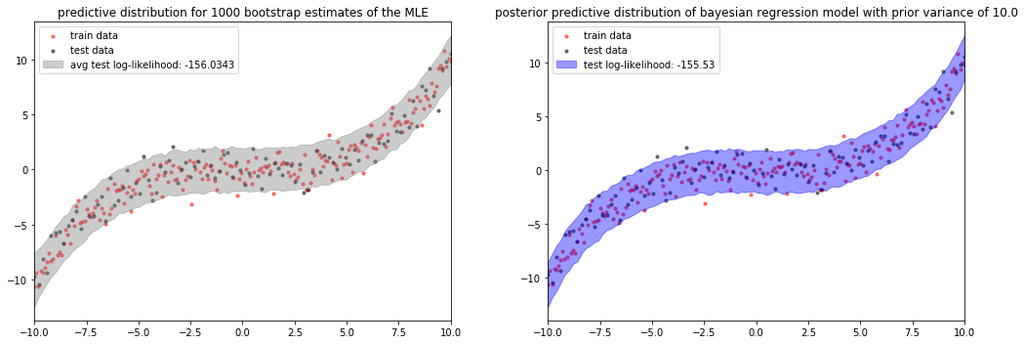

```python
fig, ax = plt.subplots(1, 2, figsize=(15, 5))
prior_var = 10.
ax, log_likelihood_bayes = mle_vs_bayesian(x_2, y_2, ax, prior_var=prior_var)
plt.tight_layout()
plt.show()
```

## Evaluating and Quantifying Uncertainty

How do we know our model uncertainties (confidence intervals, credible intervals, predcitive intervals, posterior predictive intervals) are any good? What information about the data/model do we want our uncertainties to capture?

**Epistemic Uncertainty:** uncertainty due to small number of samples across all scenarios. This can be reduced by more samples!

**Aleatoric Uncertainty:** uncertainty due to the underlying randomness of the data generation process. This cannot be reduced no matter what.

Can we use log-likelihood of as a metric for the quality of predictive uncertainty?

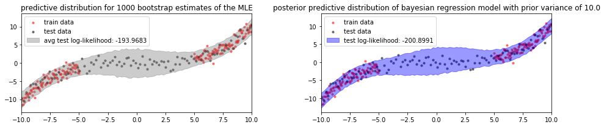

```python
fig, ax = plt.subplots(1, 2, figsize=(14, 3))
ax = mle_vs_bayesian(x_1, y_1, ax, prior_var=prior_var)
plt.tight_layout()
plt.show()
```

# Motivation for Hierarchical Models

## A Binomial Model for Movie Rankings

We model the number of likes $Y_n$ received by the $n$-th movie as a binomial variable $Y_n | \theta_n\sim Bin(R_n, \theta_n)$, where $R_n$ is the number of times the $n$-th movies was rated and $\theta_n$ is the "likeability" of the movie.

```python
#Print results of ranking
print('Top 10 Movies')
print('****************************')
for movie, likes, total_ratings, likable in top_movies:
    print (movie, ':', likable, '({}/{})'.format(likes, total_ratings))
```

[output not shown]

## A Beta-Binomial Model for Movie Rankings

We model the number of likes $Y_n$ received by the $n$-th movie as a binomial variable $Y_n | \theta_n\sim Bin(R_n, \theta_n)$, we model our prior beliefs and uncertainty about $\theta$ using a beta distribution $\theta_n \sim Beta(\alpha, \beta)$.

```
French Twist (Gazon maudit) (1995): 1.0 (2.0/2.0)
```

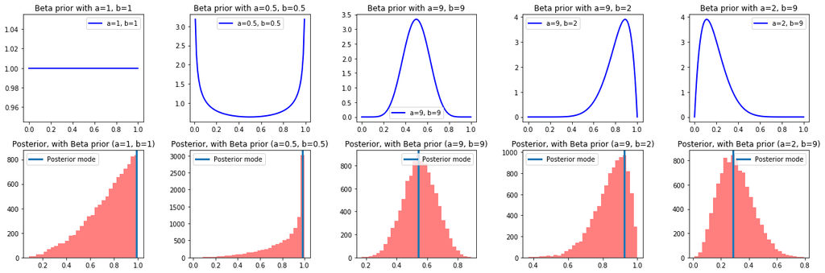

```python
print('{}: {} ({}/{})'.format(movie_name, likability, likes, total_ratings))
fig, ax = plt.subplots(2, n, figsize=(18, 6))
ax = plot_priors_with_posteriors(ax, beta_shapes, likes, total_ratings, samples)
plt.tight_layout()
plt.show()
```

## Credible Intervals for Movies with the Most and the Least Number of Ratings

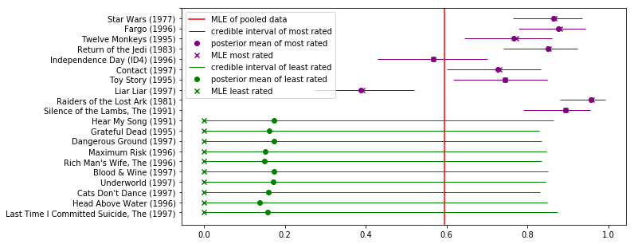

```python
fig, ax = plt.subplots(1, 1, figsize=(10, 5))
ax = plot_credible_intervals(a, b, ax)
plt.show()
```

## Emprirical Bayes (ML-II) For the Beta-Binomial Model

Since the prior has a significant impact on the posterior when the number of ratings is small, we want to choose a prior that is appropriate for the data.

**Idea:** choose the hyperparameters $\alpha, \beta$ for the beta prior such that the expected likelihood of the data, over $\theta_n \sim Beta(\alpha, \beta)$, is maximized:

\begin{aligned} p(Y_1, \ldots, Y_N| \alpha, \beta) = \prod_{n=1}^N \int_0^1 Bin(Y_n|R_n, \theta_n) Beta(\theta_n|\alpha, \beta)d\theta_n = \prod_{n=1}^N {R_n \choose Y_n}\frac{B(\alpha + Y_n, \beta + R_n - Y_n)}{B(\alpha, \beta)} \end{aligned}

where $B$ is the beta function. The marginal likelihood of the data $p(Y_1, \ldots, Y_N| a, b)$ is called *evidence*.

This method of choosing the hyperparameters of the prior based on the data is called *empirical Bayes* or *type-II maximum likelihood*.

**Question:** doens't this violate the principle of choosing the prior independent of the data?

## Method of Moments for Empirical Bayes (ML-II)

Since each marginal $p(Y_n| \alpha, \beta)$ is a Beta-Binomial distribution, we know its first two moments:

\begin{aligned} \mathbb{E}\left[Y_n\right] &= R_n \frac{\alpha}{\alpha + \beta}\\ \text{Var}\left[Y_n\right] &= \frac{R_n \alpha\beta}{(\alpha + \beta)^2}\frac{\alpha + \beta + R_n}{\alpha + \beta + 1} \end{aligned}

Now we can make the simplyfying approximations that the $Y_n$'s are iid data from the *same* binomial, i.e. all have the same moments as above. Then we can use empirical moments to approximate the theoretical moments and solve for $\alpha, \beta$:

\begin{aligned} \widehat{\mathbb{E}}\left[\frac{Y_n}{R_n}\right] &= \frac{\alpha}{\alpha + \beta}\\ \widehat{\text{Var}}\left[\frac{Y_n}{R_n}\right] &= \frac{\alpha\beta}{\overline{R}_n (\alpha + \beta)^2}\frac{\alpha + \beta + \overline{R}_n}{\alpha + \beta + 1} \end{aligned}

where $\widehat{\mathbb{E}}$ is sample mean and $\widehat{\text{Var}}$ is sample variance and $\overline{R}_n$ is the average total number of ratings.

## Empirical Bayes and Shrinkage

Computing the hyperparameters $\alpha, \beta$ of the beta prior on $\theta$ from the data, allows the ratings rich movies to influence the prior of ratings poor movies, since all movies contribute to the empirical Bayes estimate.

As a result, the estimates from ratings poor movies tend to *shrink* towards the population mean more so than ratings rich movies.

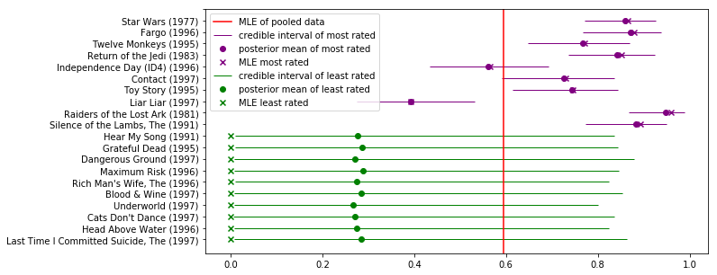

```python
fig, ax = plt.subplots(1, 1, figsize=(10, 5))
ax = plot_credible_intervals(alpha_eb, beta_eb, ax)
plt.show()
```

# Hierarchical Models and Empirical Bayes

## A Hierarchical Model for Movie Rankings

We model the number of likes $Y_n$ received by the $n$-th movie as a binomial variable $Y_n|\theta_n\sim Bin(R_n, \theta_n)$, we model our prior beliefs and uncertainty about $\theta$ using a beta distribution $\theta_n \sim Beta(\alpha, \beta)$; finally, we model our uncertainty about $\alpha, \beta$ using uniform distributions $\alpha, \beta\sim U(0.5, 100)$:

\begin{aligned} \alpha, \beta &\sim U(0.5, 100)\\ \theta_n | \alpha, \beta &\sim Beta(\alpha, \beta)\\ Y_n|\theta_n &\sim Bin(R_n, \theta_n) \end{aligned}

This is an example of a *hierarchical model* -- a model with multiple layers of unknown variables.

There are overlaps between hierarchical models and latent variable models. Generally, we want the hiearchy in a *hierarchical model* to express scientifically meaningful conditional relationships. In *latent variable models* we want the latent variable to represent unknown aspects of the data rather than unknown parameters of our model.

## Point Estimate Approximations of Inference in Hierachical Models (MAP-II)

The posterior of the hierarchical model for movie ratings is $p(\alpha, \beta, \theta_1, \ldots, \theta_N | Y_1, \ldots, Y_N)$, but since we know how $\theta_n$ is conditioned on $\alpha, \beta$, it is often easier to marginalize out $\theta_n$ and work with $p(\alpha, \beta |Y_1, \ldots, Y_N)$.

The central idea is that by infering the posterior $p(\alpha, \beta |Y_1, \ldots, Y_N)$, $\alpha$ and $\beta$ are influenced by the entire data set and thus ratings poor movies can *borrow statistical strength* from ratings rich movies through the way $\theta_n$ depends on $\alpha, \beta$.

However, performing full Bayesian inference on hierarchical models can be difficult. Thus, we can make a point estimate approximation of $p(\alpha, \beta |Y_1, \ldots, Y_N)$:

$$\alpha^*, \beta^* = \text{argmax}_{\alpha, \beta} p(\alpha, \beta |Y_1, \ldots, Y_N).$$

When we perform the usual Bayesian inference on $p(Y_n|\theta_n)p(\theta_n|\alpha^*, \beta^*)$, this is called the *type-II MAP method*.

But when $\alpha, \beta$ are uniform random varibles, the above becomes:

$$\alpha^*, \beta^* = \text{argmax}_{\alpha, \beta} p(Y_1, \ldots, Y_N |\alpha, \beta),$$

When we perform the usual Bayesian inference on $p(Y_n|\theta_n)p(\theta_n|\alpha^*, \beta^*)$, this is just our empirical Bayes or type-II MLE method!